# Project Python Foundations: FoodHub Data Analysis

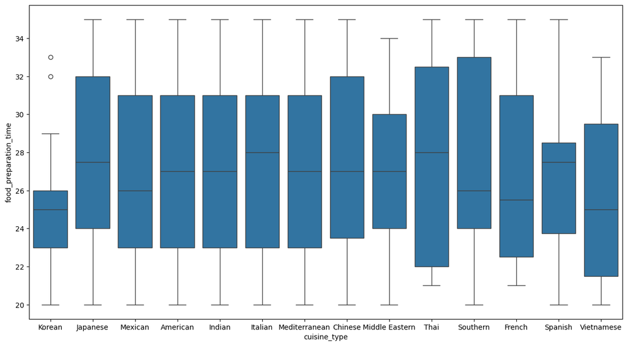

```python
# Numerical vs Categorical
plt.figure(figsize=(15,8))
sns.boxplot(x=df['cuisine_type'], y=df['food_preparation_time'])
```

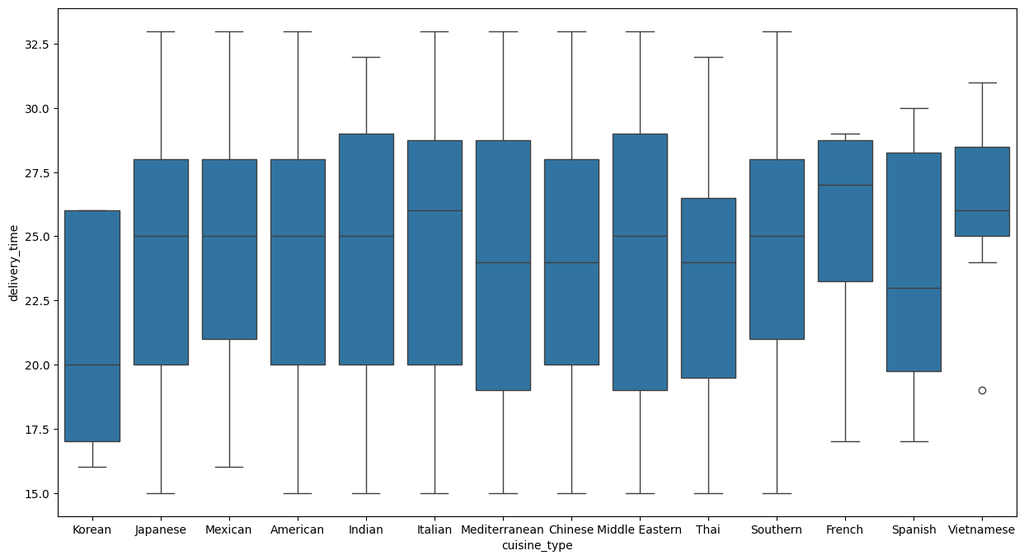

```python
# Numerical vs Categorical
plt.figure(figsize=(15,8))
sns.boxplot(x=df['cuisine_type'], y=df['delivery_time'])
```

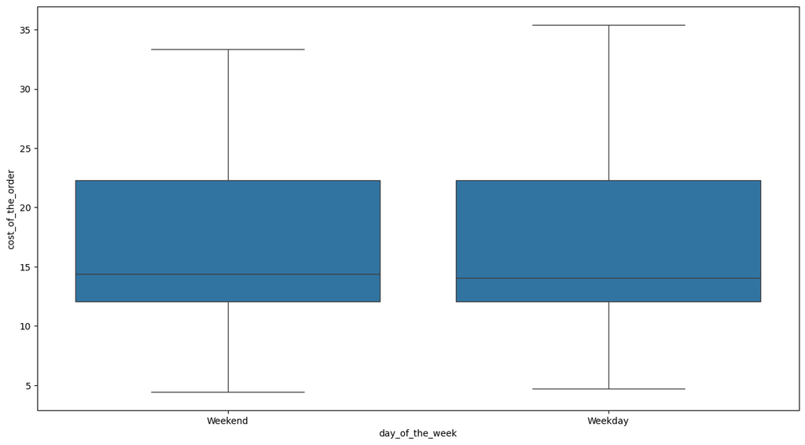

```python
# Categorical - day_of_the_week
plt.figure(figsize=(15,8))
sns.boxplot(x=df['day_of_the_week'], y=df['cost_of_the_order'])
# Observation
# There is no cost difference based on day of the week
```

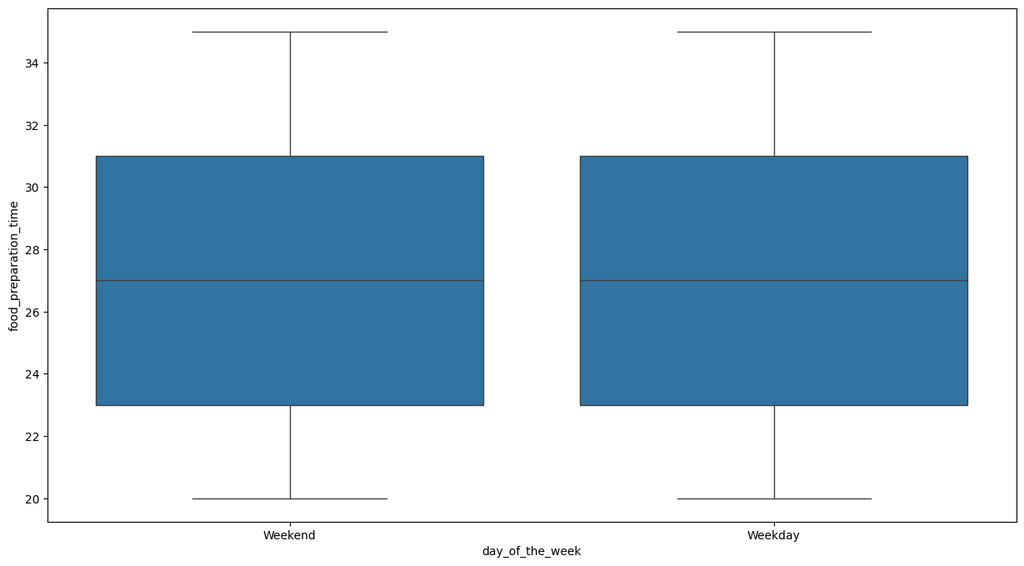

```python
plt.figure(figsize=(15,8))
sns.boxplot(x=df['day_of_the_week'], y=df['food_preparation_time'])
# Observation
# There is no difference in food preparation time based on day of the week
```

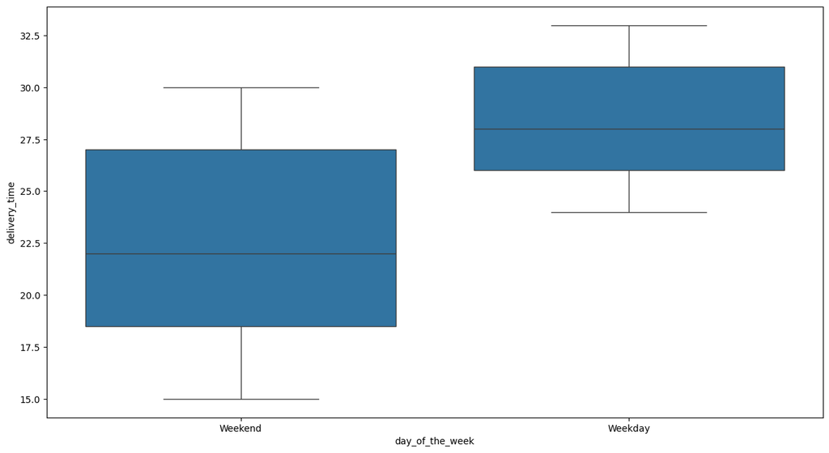

```python
plt.figure(figsize=(15,8))
sns.boxplot(x=df['day_of_the_week'], y=df['delivery_time'])
# Observation
# It shows delivery time is more in weekday
```

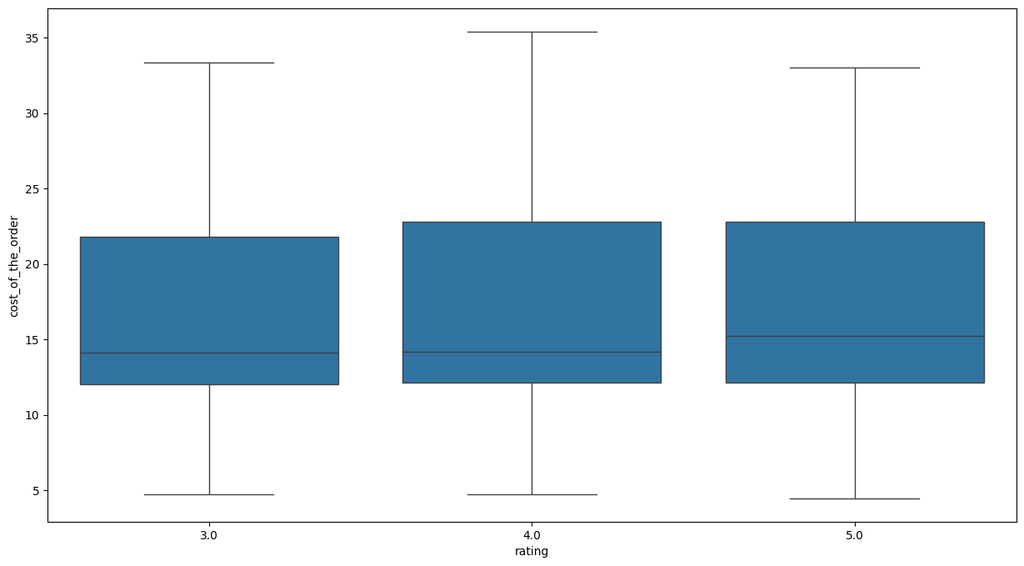

```python
# Categorical - rating
plt.figure(figsize=(15,8))
sns.boxplot(x=df['rating'], y=df['cost_of_the_order'])
```

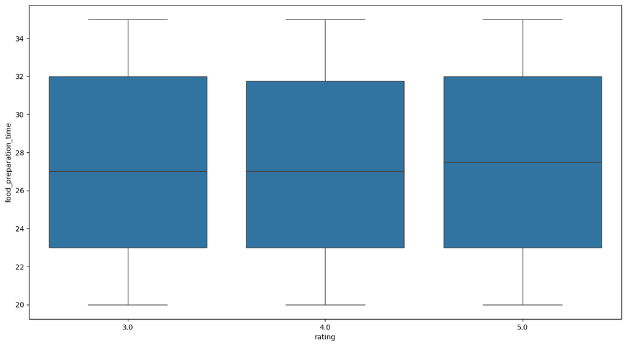

```python
plt.figure(figsize=(15,8))
sns.boxplot(x=df['rating'], y=df['food_preparation_time'])
```

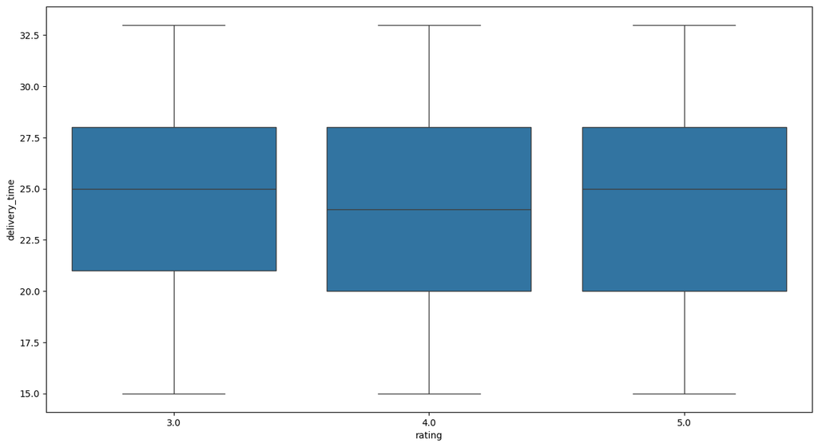

```python
plt.figure(figsize=(15,8))
sns.boxplot(x=df['rating'], y=df['delivery_time'])
```

### **Question 13:** The company wants to provide a promotional offer in the advertisement of the restaurants. The condition to get the offer is that the restaurants must have a rating count of more than 50 and the average rating should be greater than 4. Find the restaurants fulfilling the criteria to get the promotional offer. [3 marks]

```python
# Write the code here
# rating count > 50
# rating > 4
df_rating = df[df['rating'].notna()]
rating_by_rest = df_rating.groupby('restaurant_name')['rating'].agg(['count', 'mean']).reset_index()
restaurants_promotional = rating_by_rest[(rating_by_rest['count'] > 50) & (rating_by_rest['mean'] > 4)]
restaurants_promotional.head()
```

|  | restaurant_name | count | mean |
| --- | --- | --- | --- |
| 16 | Blue Ribbon Fried Chicken | 64 | 4.328125 |
| 17 | Blue Ribbon Sushi | 73 | 4.219178 |
| 117 | Shake Shack | 133 | 4.278195 |
| 132 | The Meatball Shop | 84 | 4.511905 |

[output not shown]

#### Observations:

The below restaurants get promotional offer since rating count more than 50 & avergae is greater than 4

1. Blue Ribbon Fried Chicken
2. Blue Ribbon Sushi
3. Shake Shack
4. The Meatball Shop

### **Question 14:** The company charges the restaurant 25% on the orders having cost greater than 20 dollars and 15% on the orders having cost greater than 5 dollars. Find the net revenue generated by the company across all orders. [3 marks]

```python
# Write the code here
def cal_charge (amount):
  if amount > 20:
      return amount * 0.25
  elif amount > 5:
      return amount * 0.15
  else:
    return 0

df['final_charge'] = df['cost_of_the_order'].apply(cal_charge)
revenue = df['final_charge'].sum()
print(revenue)
```

```
6166.303
```

#### Observations:

The net revenue generated by the company across all orders 6166 dollars

### **Question 15:** The company wants to analyze the total time required to deliver the food. What percentage of orders take more than 60 minutes to get delivered from the time the order is placed? (The food has to be prepared and then delivered.) [2 marks]

```python
# Write the code here
df['total'] = df['food_preparation_time'] + df['delivery_time']
df_total_greater_60 = df[df['total'] > 60]
df_total_greater_60_per = (df_total_greater_60.shape[0] / df.shape[0]) * 100
print(round(df_total_greater_60_per, 0),'%')
```

```
11.0 %
```

#### Observations:

There are 11% of orders take more than 60 minutes to get delivered from the time the order is placed

### **Question 16:** The company wants to analyze the delivery time of the orders on weekdays and weekends. How does the mean delivery time vary during weekdays and weekends? [2 marks]

```python
# Write the code here
mean_delivery_time = df.groupby('day_of_the_week')['delivery_time'].mean()
print(mean_delivery_time)
```

```
day_of_the_week
Weekday    28.340037
Weekend    22.470022
Name: delivery_time, dtype: float64
```

#### Observations:

The average delivery time during weekday is 28 minutes The average delivery time during weekend is 22 minutes

### Conclusion and Recommendations

### **Question 17:** What are your conclusions from the analysis? What recommendations would you like to share to help improve the business? (You can use cuisine type and feedback ratings to drive your business recommendations.) [6 marks]

### Conclusions:

1. Customers ordered more foods from American cuisines with 584 orders. The next highest is Japanese with 470 orders. The least customer preferred cuisine is Vietnamese with 7 orders.
2. Customers ordered most of the food has cost around 12 dollars
3. Customers ordered most of the foods in weekend when compared to weekdays. 1351 orders in weekend & 547 orders in weekday out of 1898 total orders.
4. Customers didn’t provide rating for 736 orders out of 1898 orders.

### Recommendations:

1. Food Hub need to add more American cuisines to get more revenue when compared to other cuisine types
2. Restaurant should introduce more foods around cost range from 11 to 12 dollars, since this is the affordable cost for customers
3. Customers ordered more food in weekend. So Restuarants should give offer in weekdays to get more revenue.
4. Food Hub should give promotional offers to customers for giving rating of the food orders. The rating will give more insights about the business & it will help business to identify the areas to imporove.